# BetaStability Quick Start Guide

Yu Gao(gaoyu19920914@gmail.com)

2026-10-02

# BetaStability Quick Start Guide

This vignette demonstrates the capabilities of the BetaStability package using the `varespec` and `varechem` datasets from the vegan package.

## Installation

First, install the package from GitHub:

```r
# Install from GitHub
# install.packages("devtools")
# devtools::install_github("gaoyu19920914/betaStability")

# OR install from BioConductor (in the future when it's available)
# if (!requireNamespace("BiocManager", quietly = TRUE))
#     install.packages("BiocManager")
# BiocManager::install("betaStability")
```

## Loading Required Packages

Load the BetaStability package and the vegan package for test data:

```r
library(betaStability)
library(vegan)
```

```r
library(ggplot2)
```

## Loading Test Data

Load the `varespec` (community data) and `varechem` (environmental metadata) datasets from the vegan package:

```r
data(varespec)
data(varechem)

# Inspect the data
head(varespec)
```

```
#>    Callvulg Empenigr Rhodtome Vaccmyrt Vaccviti Pinusylv Descflex Betupube Vacculig Diphcomp Dicrsp Dicrfusc
#> 18     0.55    11.13     0.00     0.00    17.80     0.07     0.00        0     1.60     2.07   0.00     1.62
#> 15     0.67     0.17     0.00     0.35    12.13     0.12     0.00        0     0.00     0.00   0.33    10.92
#> 24     0.10     1.55     0.00     0.00    13.47     0.25     0.00        0     0.00     0.00  23.43     0.00
#> 27     0.00    15.13     2.42     5.92    15.97     0.00     3.70        0     1.12     0.00   0.00     3.63
#> 23     0.00    12.68     0.00     0.00    23.73     0.03     0.00        0     0.00     0.00   0.00     3.42
#> 19     0.00     8.92     0.00     2.42    10.28     0.12     0.02        0     0.00     0.00   0.00     0.32
#>    Dicrpoly Hylosple Pleuschr Polypili Polyjuni Polycomm Pohlnuta Ptilcili Barbhatc Cladarbu Cladrang Cladstel
#> 18     0.00      0.0     4.67     0.02     0.13     0.00     0.13     0.12     0.00    21.73    21.47     3.50
#> 15     0.02      0.0    37.75     0.02     0.23     0.00     0.03     0.02     0.00    12.05     8.13     0.18
#> 24     1.68      0.0    32.92     0.00     0.23     0.00     0.32     0.03     0.00     3.58     5.52     0.07
#> 27     0.00      6.7    58.07     0.00     0.00     0.13     0.02     0.08     0.08     1.42     7.63     2.55
#> 23     0.02      0.0    19.42     0.02     2.12     0.00     0.17     1.80     0.02     9.08     9.22     0.05
#> 19     0.02      0.0    21.03     0.02     1.58     0.18     0.07     0.27     0.02     7.23     4.95    22.08
#>    Cladunci Cladcocc Cladcorn Cladgrac Cladfimb Cladcris Cladchlo Cladbotr Cladamau Cladsp Cetreric Cetrisla
#> 18     0.30     0.18     0.23     0.25     0.25     0.23     0.00     0.00     0.08   0.02     0.02     0.00
#> 15     2.65     0.13     0.18     0.23     0.25     1.23     0.00     0.00     0.00   0.00     0.15     0.03
#> 24     8.93     0.00     0.20     0.48     0.00     0.07     0.10     0.02     0.00   0.00     0.78     0.12
#> 27     0.15     0.00     0.38     0.12     0.10     0.03     0.00     0.02     0.00   0.02     0.00     0.00
#> 23     0.73     0.08     1.42     0.50     0.17     1.78     0.05     0.05     0.00   0.00     0.00     0.00
#> 19     0.25     0.10     0.25     0.18     0.10     0.12     0.05     0.02     0.00   0.00     0.00     0.00
#>    Flavniva Nepharct Stersp Peltapht Icmaeric Cladcerv Claddefo Cladphyl
#> 18     0.12     0.02   0.62     0.02        0        0     0.25        0
#> 15     0.00     0.00   0.85     0.00        0        0     1.00        0
#> 24     0.00     0.00   0.03     0.00        0        0     0.33        0
#> 27     0.00     0.00   0.00     0.07        0        0     0.15        0
#> 23     0.02     0.00   1.58     0.33        0        0     1.97        0
#> 19     0.02     0.00   0.28     0.00        0        0     0.37        0
```

```r
head(varechem)
```

```
#>       N    P     K    Ca    Mg    S    Al   Fe    Mn   Zn  Mo Baresoil Humdepth  pH
#> 18 19.8 42.1 139.9 519.4  90.0 32.3  39.0 40.9  58.1  4.5 0.3     43.9      2.2 2.7
#> 15 13.4 39.1 167.3 356.7  70.7 35.2  88.1 39.0  52.4  5.4 0.3     23.6      2.2 2.8
#> 24 20.2 67.7 207.1 973.3 209.1 58.1 138.0 35.4  32.1 16.8 0.8     21.2      2.0 3.0
#> 27 20.6 60.8 233.7 834.0 127.2 40.7  15.4  4.4 132.0 10.7 0.2     18.7      2.9 2.8
#> 23 23.8 54.5 180.6 777.0 125.8 39.5  24.2  3.0  50.1  6.6 0.3     46.0      3.0 2.7
#> 19 22.8 40.9 171.4 691.8 151.4 40.8 104.8 17.6  43.6  9.1 0.4     40.5      3.8 2.7
```

```r
# Dimensions of the datasets
cat("Dimensions of varespec:", dim(varespec), "\n")
```

```
#> Dimensions of varespec: 24 44
```

```r
cat("Dimensions of varechem:", dim(varechem), "\n")
```

```
#> Dimensions of varechem: 24 14
```

## Calculating Stability with Single Method

Calculate stability using a single prediction method (`linearPred`):

```r
# Calculate stability with linearPred
result_linear <- betaStability(
    comtable = varespec,
    envmeta = varechem,
    method = "linearPred"
)

# Inspect the result
head(result_linear)
```

```
#>    stability_Linear
#> 18       0.10957916
#> 15       0.04122119
#> 24       0.03322119
#> 27       0.01357100
#> 23       0.10483057
#> 19       0.15983875
```

```r
length(result_linear)
```

```
#> [1] 1
```

## Calculating Stability with Multiple Methods

Calculate stability using multiple prediction methods:

```r
# Calculate stability with multiple methods
results_multi <- betaStability(
    comtable = varespec,
    envmeta = varechem,
    method = c("linearPred", "mlPred", "glmPred")
)

# Inspect the result
head(results_multi)
```

```
#>    linearPred      mlPred     glmPred
#> 18 0.10957916  0.10697541  0.09500812
#> 15 0.04122119  0.04948000  0.01670908
#> 24 0.03322119 -0.48026478 -0.20949112
#> 27 0.01357100  0.03842571  0.02746107
#> 23 0.10483057  0.12130661  0.09890176
#> 19 0.15983875  0.26114780  0.20125198
```

```r
dim(results_multi)
```

```
#> [1] 24  3
```

## Calculating Stability with All Methods

Calculate stability using all available prediction methods:

```r
# Calculate stability with all methods
results_all <- betaStability(
    comtable = varespec,
    envmeta = varechem,
    method = "all"
)

# Inspect the result
head(results_all)
```

```
#>    linearPred      mlPred     glmPred     gamPred     gdmPred      rfPred xgboostPred
#> 18 0.10957916  0.10697541  0.09373407  0.01719127  0.12600785  0.10018222  0.09206358
#> 15 0.04122119  0.04948000  0.01687718 -0.02551985  0.05920659  0.01628172  0.02510648
#> 24 0.03322119 -0.48026478 -0.21015617 -0.13782392 -0.13878658 -0.21489886 -0.25652045
#> 27 0.01357100  0.03842571  0.02662996 -0.03525648  0.07550562  0.01931343  0.02518945
#> 23 0.10483057  0.12130661  0.09887233  0.03382381  0.08270438  0.09435799  0.06493194
#> 19 0.15983875  0.26114780  0.20126550  0.09397862  0.16207300  0.18880189  0.20346170
```

```r
dim(results_all)
```

```
#> [1] 24  7
```

```r
colnames(results_all)
```

```
#> [1] "linearPred"  "mlPred"      "glmPred"     "gamPred"     "gdmPred"     "rfPred"      "xgboostPred"
```

## Visualizing Stability Results

Visualize the stability results using the `plotStability` function:

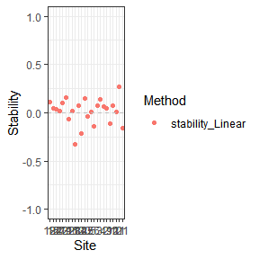

```r
# Plot stability results for single method
p1 <- plotStability(result_linear)
p1
```

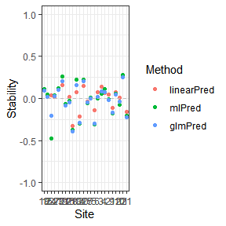

```r
# Plot stability results for multiple methods
p2 <- plotStability(results_multi)
p2
```

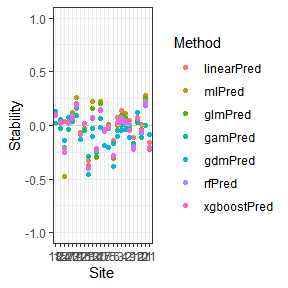

```r
# Plot stability results for all methods
p3 <- plotStability(results_all)
p3
```

Visualize the correlations between different stability quantifying methods using the `plotCorrelation` function:

[figure not shown]

```r
# Plot stability correlations between all pairs of methods
p4 <- plotCorrelation(results_all)
p4
```

## Customizing Site Names

You can also customize the site names in the plot:

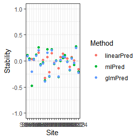

```r
# Create custom site names
custom_sitenames <- paste("Site", seq_len(nrow(varespec)))

# Plot with custom site names
p5 <- plotStability(results_multi, sitenames = custom_sitenames)
p5
```

## Conclusion

The BetaStability package provides a comprehensive framework for calculating and visualizing site stability using various prediction methods. Key features include:

1. **Multiple prediction methods**: Choose from linear, multiple linear model, generalized linear model, generalized additive model, generalized dissimilarity model, random forest, and xgboost models.
2. **Flexible input options**: Use precomputed distance matrices or let the package compute them automatically.
3. **Easy visualization**: The `plotStability` function creates informative plots of stability results.
4. **Convenient “all” method**: Run all prediction methods with a single parameter setting and receive a summary of results.

This package is designed to help researchers and ecologists assess site stability based on the beta stability of communities, providing valuable insights for ecosystem management.